# Exploring Forest Fires with Metereological Data

agrou

### Summary

The objective of this report is to provide an exploratory data analysis of the forest fires data and plan for reproducing the analysis done by the authors Cortez and Morais.

### Background

The authors used different data mining techniques and four feature selection setups (spacial, temporal, FWI system and metereological data). “The proposed solution includes only four weather variables (i.e. rain, wind, temperature and humidity) in conjunction with a SVM and it is capable of predicting the burned area of small fires, which constitute the majority of the fire oc-currences. Such knowledge is particularly useful for fire management decision support (e.g. resource planning). For more info see the [full article](http://www.dsi.uminho.pt/~pcortez/fires.pdf) and [website](http://www3.dsi.uminho.pt/pcortez/forestfires/)

### Information about the data:

**Nature of the data:** Real-time and non-costly metereological data. Recent real-world data, collected from the northeast region of Portugal, with the aim of predicting the burned area (or size) of forest fires.

**Institution in charge of data management:** Bragança Polytechnic Institute and the Inspector responsible for Montesinho fire occurences. Data provided by Professor Paulo Cortez.

**Date/period of data collection:** From January 2000 to December 2003

**Potential bias in the statistical design:**

It is not clear how data was put together regarding the identification of the different years. There is no variable correspondent to year (from Jan 2000 to Dec 2003).

**Methods of data collection:** Data was built using two sources:

- “The first database was collected by the inspector that was responsible for the Montesinho fire occurences. At a daily basis, every time a forest fire occured, several features were registered such as the time, date, spatial location within a 9x9 grid, the type of vegetation involved, the six components of the FWI system and the total burned area.”
- “The second database was collected by the Bragança Polytechnic Institute, containing several weather observations (e.g. wind speed) that were recorded with a 30 minute period by a metereological station located in the center of the Montesinho park.”

“The two databases were stored in tens of individual spreadsheets, under distinct formats, and a substantial manual effort was performed to integrate them into a single dataset with a total of 517 entries.”

### Our Exploratory Data Analysis Objectives

- Explore and describe the data to understand constraints, limitations and other data features/characteristics.
- Understand the extent of area measured as being affected by the fires (summary statistics, prevalence)

Hypothesis: We expect to find similar results as the ones presented in the [study](http://www.dsi.uminho.pt/~pcortez/fires.pdf)

**Questions**

- What’s the first thing we’re going to do with this data project?
- What are the key variables to identify fire burnt area?
- What kind of data cleaning and processing is required?
- How can we predict future fires?

### Exploratory Data Analysis

Load required libraries

```r
library(readr)
library(tidyverse)
library(summarytools)
library(ggplot2)
library(scales)
library(ggthemes)
library(party)
library(forcats)
library(stringr)
```

Read the data

```r
forest_data <- read_csv("data/forestfires.csv")
```

**Understand the data variables**

In the available documentation there’s a text file with information for each variable. Further details can be found in the full article.

- X and Y are x-axis and y-axis (respectively) for spatial coordinates within the [Montesinho park](https://www.google.pt/maps/place/Montesinho+Natural+Park/@40.7181411,-9.1849886,8.1z/data=!4m5!3m4!1s0xd3a4f6625fa02dd:0x72771d4ab83da54d!8m2!3d41.8000703!4d-6.7610949?dcr=0)
- month is the month of the year from “jan” to “dec”
- day is the day of the week from “mon” to “sun”

The next six variables are components of the FWI:

**Fuel codes**

- FFMC: Fine Fuel Moisture Code - 18.7 to 96.20 (denotes the moisture content surface litter and influences ignition and fire spread)
- DMC: Duff Moisture Code - 1.1 to 291.3
- DC: Drought Code - 7.9 to 860.6

*“Fuel moisture codes require a memory (time lag) of past weather conditions: 16 hours for FFMC, 12 days for DMC and 52 days for DC.”*

DMC and DC represent the moisture content of shallow and deep organic layers, which affect fire intensity.

**Fire behaviour indexes**

- ISI - ISI index from the FWI system: 0.0 to 56.10 (a score that correlates with fire velocity spread) FWI index is an indicator of fire intensity and combines the amount of fuel available (BUI) and ISI. High values suggest more severe burning conditions.

**Weather observations or forecasts**

- temp - outside temperature in Celsius degrees: 2.2 to 33.30
- RH - relative humidity in %: 15.0 to 100
- wind - wind speed in km/h: 0.40 to 9.40
- rain - outside rain in mm/m2 : 0.0 to 6.4
- area - the burned area of the forest (in ha): 0.00 to 1090.84 (this output variable is very skewed towards 0.0, thus it may make sense to model with the logarithm transform).

**Data transformations rationale**

“There are 247 samples with a zero value. (…) all entries denote fire occurences and zero value means than an area lower than 1*ha*/100 = 100m^2 was burned. To reduce skewness and improve symmetry, the logarithm function y = ln(x + 1), which is a common transformation that tends to improve regression results for right-skewed targets, was applied to the area attribute. The final transformed variable will be the output target of this work.”

**Descriptive summaries**

Which is the most frequent month in the data?

```r
freq(forest_data$month, style = "rmarkdown")
```

```
## ## Frequencies
## **month  **
## **Data frame:** forest_data
## **Type:** Character
##
## |     &nbsp; | Freq | % Valid | % Valid Cum. | % Total | % Total Cum. |
## |-----------:|-----:|--------:|-------------:|--------:|-------------:|
## |    **apr** |    9 |    1.74 |         1.74 |    1.74 |         1.74 |
## |    **aug** |  184 |   35.59 |        37.33 |   35.59 |        37.33 |
## |    **dec** |    9 |    1.74 |        39.07 |    1.74 |        39.07 |
## |    **feb** |   20 |    3.87 |        42.94 |    3.87 |        42.94 |
## |    **jan** |    2 |    0.39 |        43.33 |    0.39 |        43.33 |
## |    **jul** |   32 |    6.19 |        49.52 |    6.19 |        49.52 |
## |    **jun** |   17 |    3.29 |        52.80 |    3.29 |        52.80 |
## |    **mar** |   54 |   10.44 |        63.25 |   10.44 |        63.25 |
## |    **may** |    2 |    0.39 |        63.64 |    0.39 |        63.64 |
## |    **nov** |    1 |    0.19 |        63.83 |    0.19 |        63.83 |
## |    **oct** |   15 |    2.90 |        66.73 |    2.90 |        66.73 |
## |    **sep** |  172 |   33.27 |       100.00 |   33.27 |       100.00 |
## | **\<NA\>** |    0 |         |              |    0.00 |       100.00 |
## |  **Total** |  517 |  100.00 |       100.00 |  100.00 |       100.00 |
```

There’s more measurements in August, followed by September and March.

```r
descr(forest_data, stats = c("mean", "sd", "min", "med", "max"), transpose = TRUE)
```

```
## Non-numerical variable(s) ignored: month, day
```

```
## Descriptive Statistics
## Data Frame: forest_data
## N: 517
##
##                Mean   Std.Dev     Min   Median       Max
## ---------- -------- --------- ------- -------- ---------
##          X     4.67      2.31    1.00     4.00      9.00
##          Y     4.30      1.23    2.00     4.00      9.00
##       FFMC    90.64      5.52   18.70    91.60     96.20
##        DMC   110.87     64.05    1.10   108.30    291.30
##         DC   547.94    248.07    7.90   664.20    860.60
##        ISI     9.02      4.56    0.00     8.40     56.10
##       temp    18.89      5.81    2.20    19.30     33.30
##         RH    44.29     16.32   15.00    42.00    100.00
##       wind     4.02      1.79    0.40     4.00      9.40
##       rain     0.02      0.30    0.00     0.00      6.40
##       area    12.85     63.66    0.00     0.52   1090.84
```

According to the article the average annual temperature is *“within the range of 8 to 12ºC”*. The average temperature collected in these data is `18.89 ºC` with a standard deviation of `5.81`

Distribution of measurements

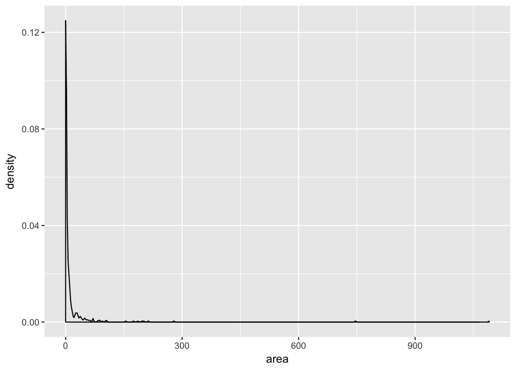

```r
ggplot() + geom_density(data = forest_data, aes(x = area), binwidth = function(x) 2 * IQR(x) / (length(x)^(1/3)))
```

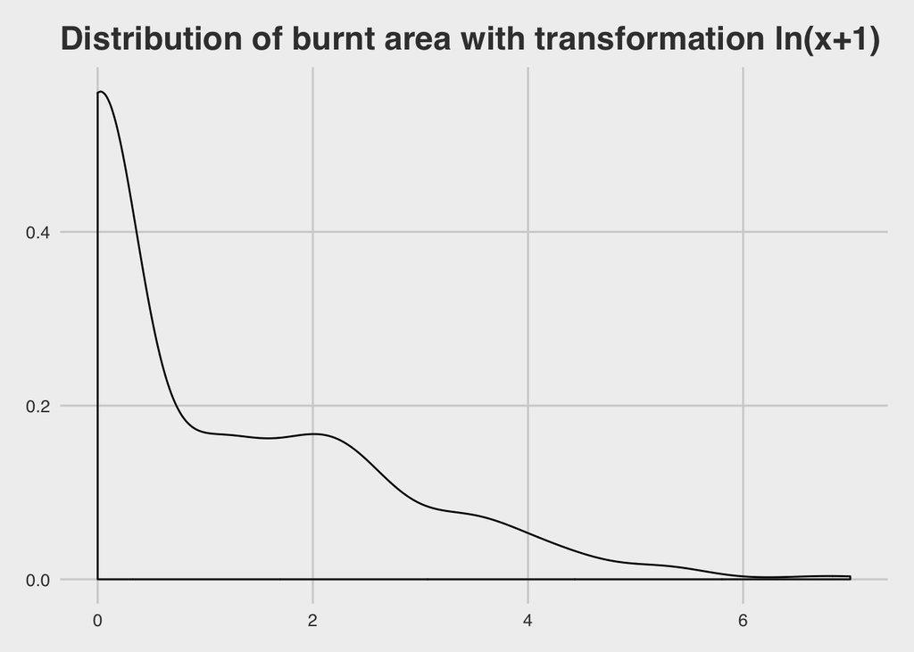

```r
ggplot() +
        geom_density(data = forest_data, aes(x = log1p(area)), binwidth = function(x) 2 * IQR(x) / (length(x)^(1/3))) +
        theme_fivethirtyeight() +
        labs(title = "Distribution of burnt area with transformation ln(x+1)")
```

With geom_density() the area under the curve is one. Whereas with geom_histogram() it would become harder to compare, since there are two many counts for small fires.

Order months and convert month variable to factor

```r
forest_dat <- forest_data %>%
        mutate(month_numeric = match(month, str_to_lower(month.abb))) %>%
        arrange(month_numeric) %>%
        mutate(month = as_factor(month),
               day = ordered(day, levels = c("mon", "tue", "wed", "thu", "fri", "sat", "sun")))
forest_dat
```

```
## # A tibble: 517 x 14
##        X     Y  month   day  FFMC   DMC    DC   ISI  temp    RH  wind
##    <int> <int> <fctr> <ord> <dbl> <dbl> <dbl> <dbl> <dbl> <int> <dbl>
##  1     2     4    jan   sat  82.1   3.7   9.3   2.9   5.3    78   3.1
##  2     4     5    jan   sun  18.7   1.1 171.4   0.0   5.2   100   0.9
##  3     2     2    feb   mon  84.0   9.3  34.0   2.1  13.9    40   5.4
##  4     2     2    feb   fri  86.6  13.2  43.0   5.3  12.3    51   0.9
##  5     9     9    feb   thu  84.2   6.8  26.6   7.7   6.7    79   3.1
##  6     9     9    feb   fri  86.6  13.2  43.0   5.3  15.7    43   3.1
##  7     3     4    feb   sat  83.9   8.0  30.2   2.6  12.7    48   1.8
##  8     4     6    feb   sat  68.2  21.5  87.2   0.8  15.4    40   2.7
##  9     5     4    feb   sun  86.8  15.6  48.3   3.9  12.4    53   2.2
## 10     7     4    feb   sun  83.9   8.7  32.1   2.1   8.8    68   2.2
## # ... with 507 more rows, and 3 more variables: rain <dbl>, area <dbl>,
## #   month_numeric <int>
```

```r
levels(forest_dat$month)
```

```
##  [1] "jan" "feb" "mar" "apr" "may" "jun" "jul" "aug" "sep" "oct" "nov"
## [12] "dec"
```

```r
levels(forest_dat$day)
```

```
## [1] "mon" "tue" "wed" "thu" "fri" "sat" "sun"
```

### Exploring covariation between variables

Proportion of measurements by month

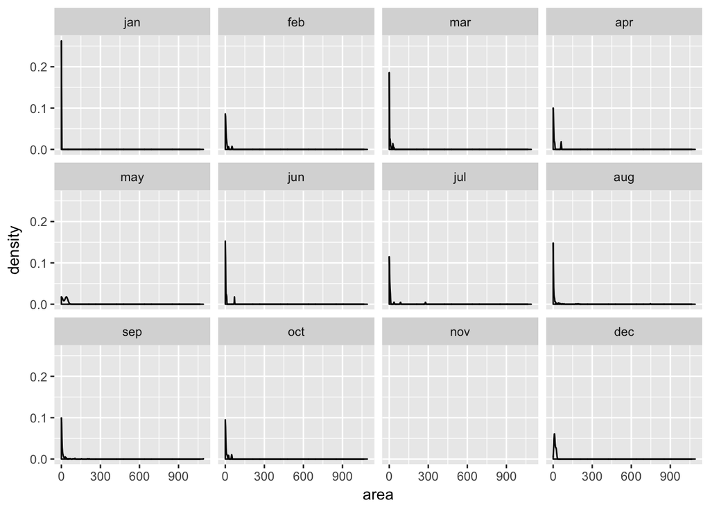

```r
ggplot() + geom_density(data = forest_dat, aes(x = area)) + facet_wrap(~month)
```

Measurement counts of burnt area by month - log transformation. `lop1p` function computes ln(x+1) transformation

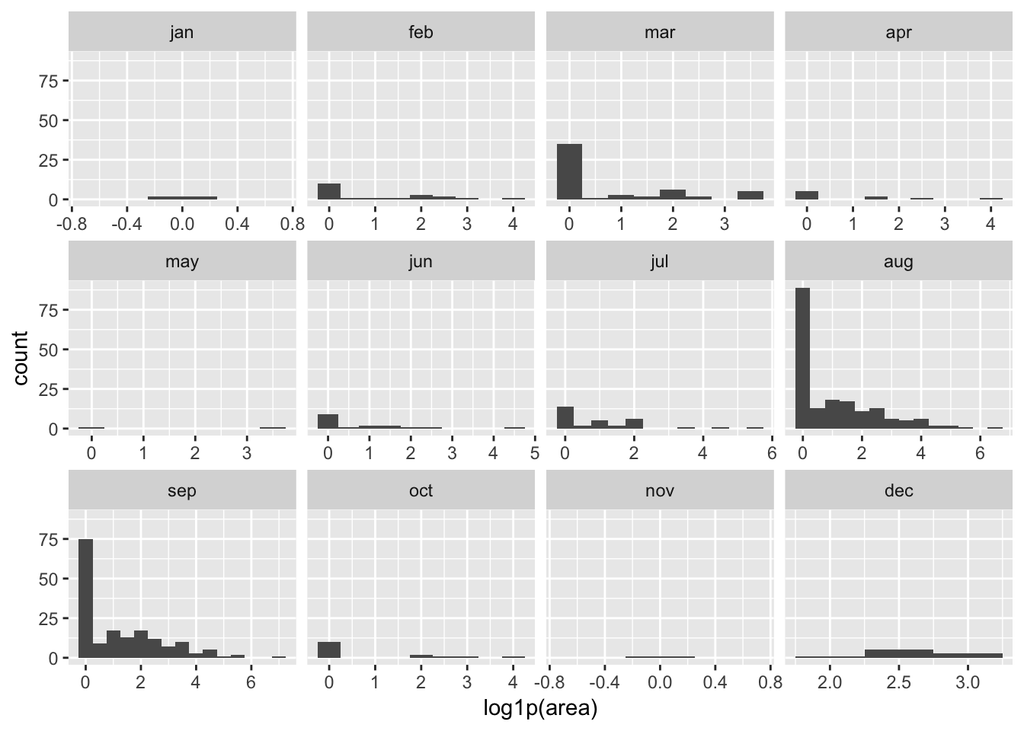

```r
ggplot() + geom_histogram(data = forest_dat, aes(x = log1p(area)), binwidth = 0.5) +
        #scale_x_log10() +
        facet_wrap(~month, scales = 'free_x')
```

The log transformation helps to visualize the data with the assumption of a normal distribution, correcting for the skewness we saw in the density. In January and November there where no positive burnt area values.

Proportion of measurements in each month

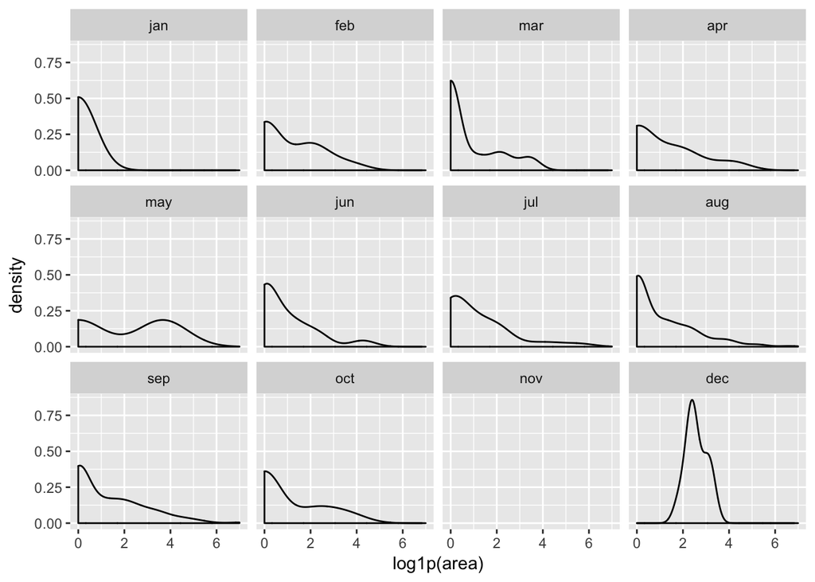

```r
ggplot(forest_dat, aes(x = log1p(area))) +
        geom_density() +
        facet_wrap(~month)
```

We can see less variability of area measurements in December and wider distributions in August and September. There seem to be less small fires in december compared to the rest of the months and less than two occurences in november.

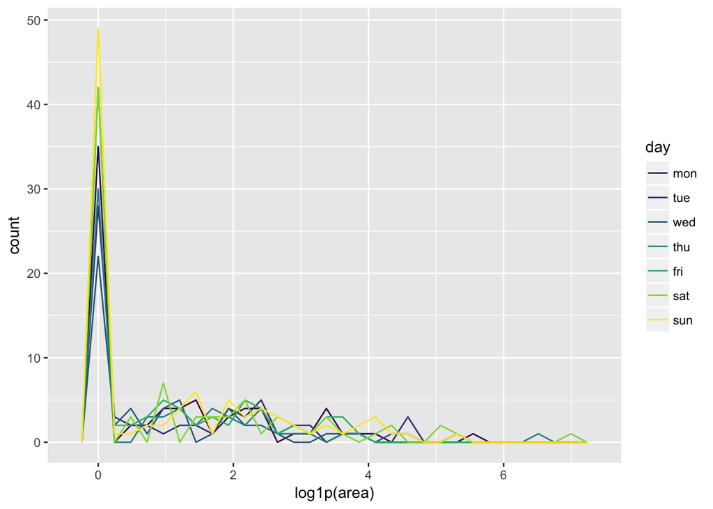

```r
ggplot(forest_dat, aes(x = log1p(area))) +
        geom_freqpoly(aes(color = day)) #+
```

```r
        #facet_wrap(~day)
```

```r
table(forest_dat$day)
```

```
##
## mon tue wed thu fri sat sun
##  74  64  54  61  85  84  95
```

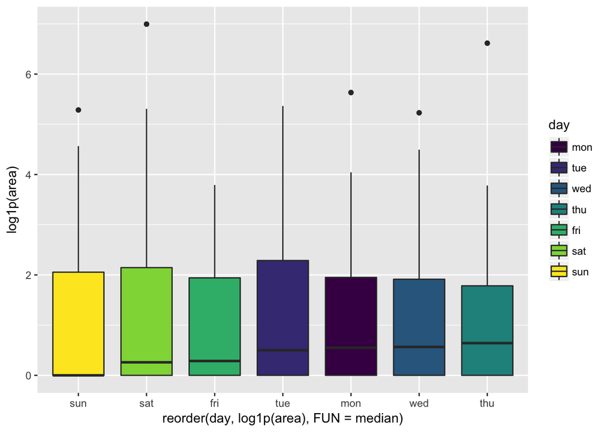

```r
ggplot(forest_dat, aes(x = reorder(day, log1p(area), FUN = median), y = log1p(area))) +
        geom_boxplot(aes(fill = day))
```

The plot shows lower median values of area burnt on the weekend. However it doesn’t seem to be significantly different from the rest of the weekdays.

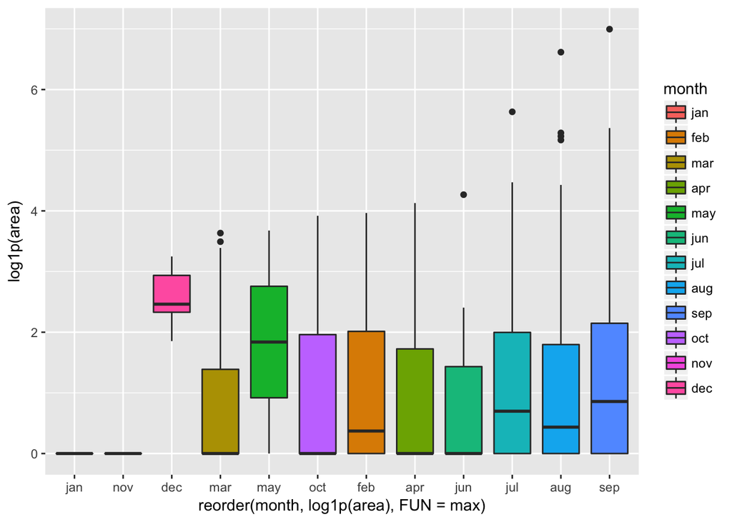

```r
ggplot(forest_dat, aes(x = reorder(month, log1p(area), FUN = max), y = log1p(area))) +
        geom_boxplot(aes(fill = month))
```

We must take into consideration that some months have a much lower count of measurements, such as December, than other months. Thus it influences the average.

What about data distribution by week day?

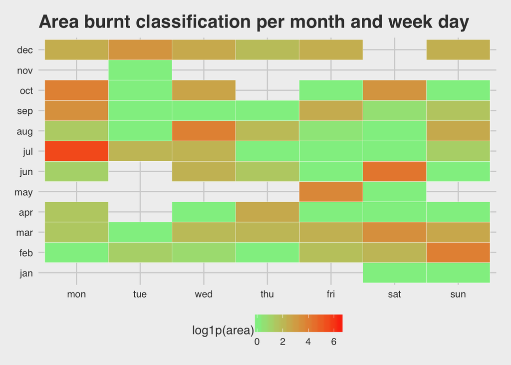

```r
ggplot(forest_dat, aes(day, month, fill = log1p(area))) +
        geom_tile(colour = "white") +
        theme_fivethirtyeight() +
        scale_fill_gradient(low = "lightgreen", high = "red") +
        labs(title = "Area burnt classification per month and week day ")
```

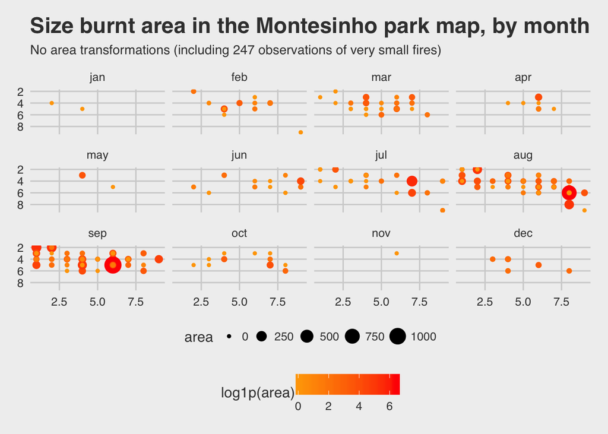

```r
ggplot(data = forest_dat, aes(x = X, y = Y)) +
        geom_point(aes(size = area, colour = log1p(area))) +
        scale_colour_gradient(low = "orange", high = "red") +
        scale_y_reverse() +
        theme_fivethirtyeight() +
        facet_wrap(~month) +
        labs(title = "Size burnt area in the Montesinho park map, by month",
             subtitle = "No area transformations (including 247 observations of very small fires)")
```

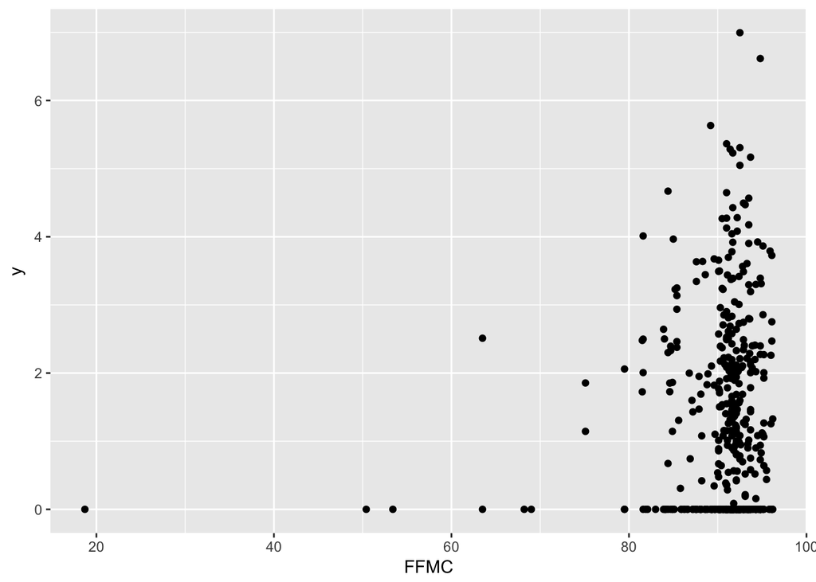

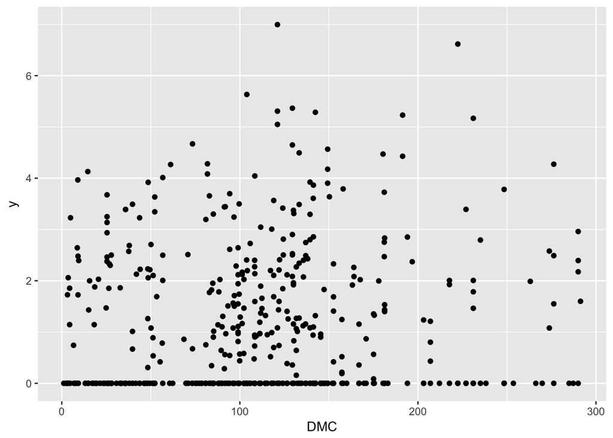

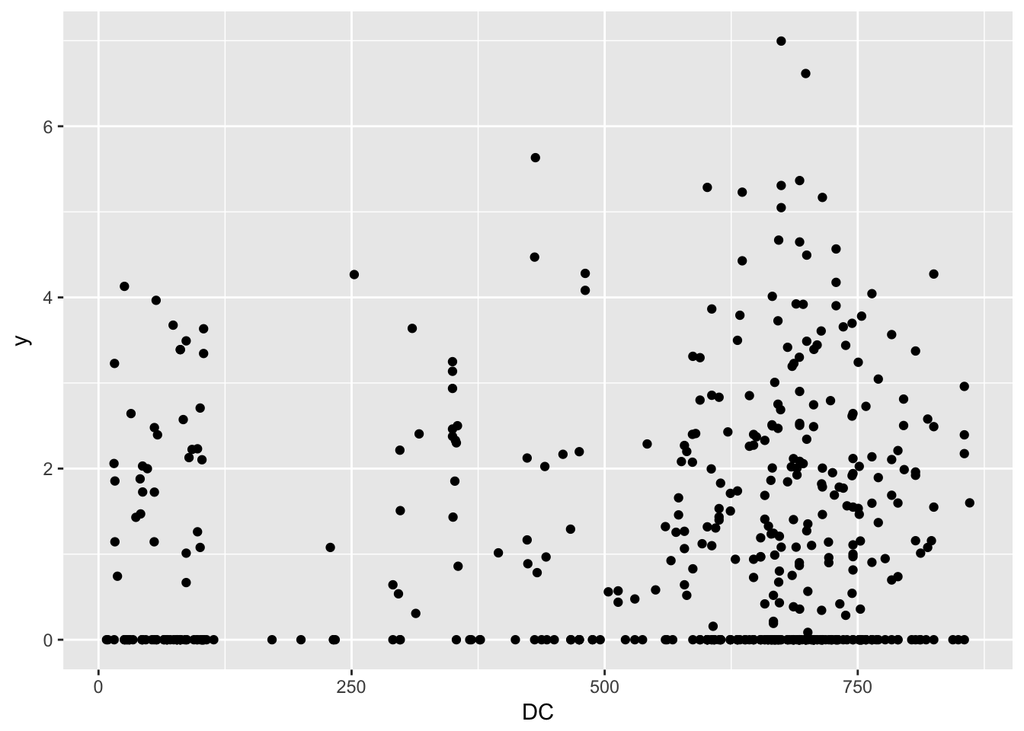

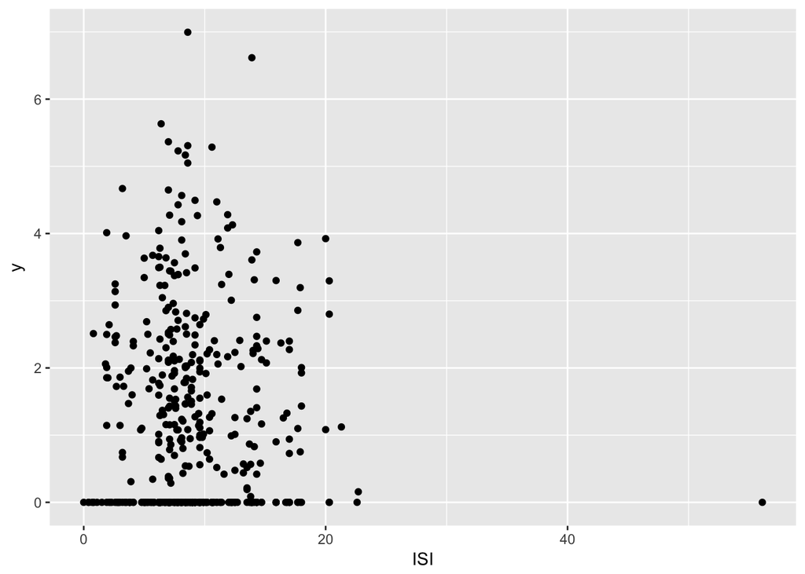

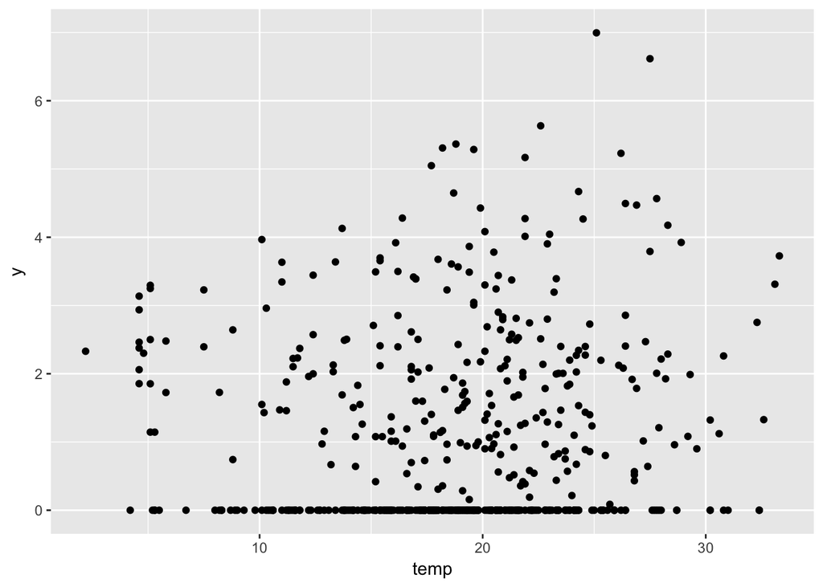

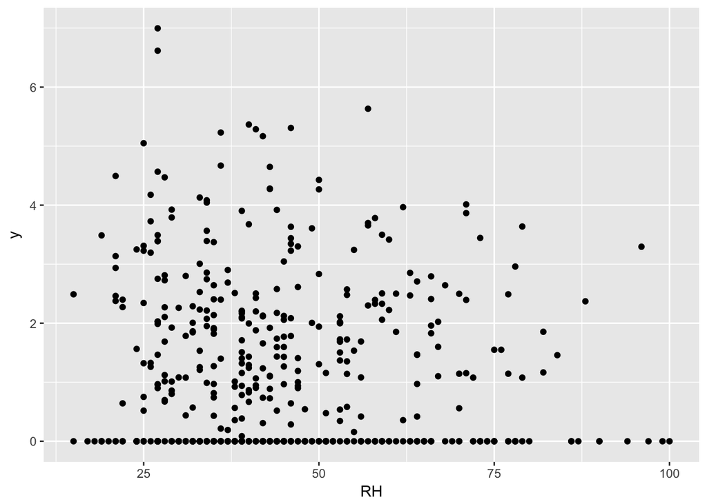

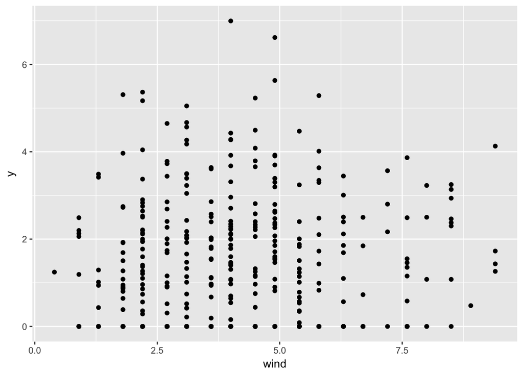

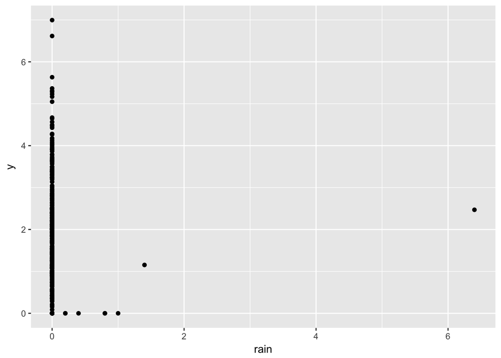

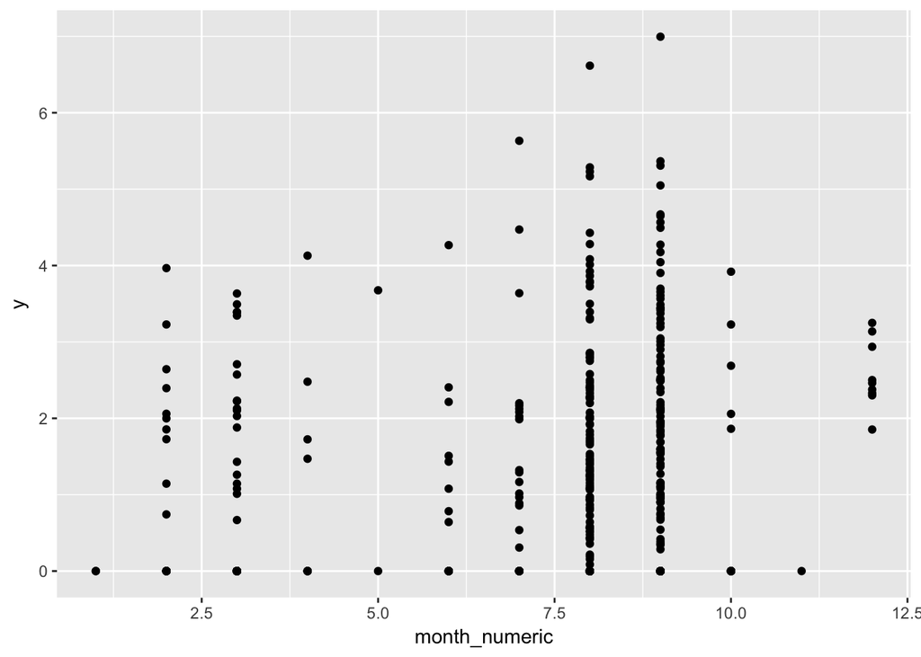

```r
forest_dat %>%
       select_if(is.numeric) %>%
        select(-area, -X, -Y) %>%
        names() %>%
        map(
                ~ggplot(forest_dat, aes_string(x = ., y = log1p(forest_dat$area))) +
                    geom_point()
        )
```

### References

- P. Cortez and A. Morais. A Data Mining Approach to Predict Forest Fires using Meteorological Data. In J. Neves, M. F. Santos and J. Machado Eds., New Trends in Artificial Intelligence, Proceedings of the 13th EPIA 2007 - Portuguese Conference on Artificial Intelligence, December, Guimaraes, Portugal, pp. 512-523, 2007. APPIA, ISBN-13 978-989-95618-0-9. Available at: http://www.dsi.uminho.pt/~pcortez/fires.pdf
- European Food Safety Authority, 2014. Guidance on Statistical Reporting. EFSA Journal 2014;12(12):3908, 18pp.,doi:10.2903/j.efsa.2014.3908. Available online: www.efsa.europa.eu/efsajournal
- Summary Tools: https://github.com/dcomtois/summarytools
- Logarithms and Exponentials: http://astrostatistics.psu.edu/su07/R/html/base/html/Log.html